# 21_param_estimation_intro slides

### Statistical Modeling and Generative Modeling

- Generative models are expressive representations of the data generating process
  - A generative model describes how likely a given example is to be generated
  - Having access to a distributions params was very useful to answer the different types of questions we have been interested in so far:
1. Probability and expectation and variance of distribution
2. Hypothesis testing
- Most often we don't have access parameters that generated the data
- Therefore, we need to estimate those params from a small sample.

### Statistical Modeling - Cont'd

- Contrary to generative models, to estimate a distributions's parameter's we work from the data upwards
- This upward–reasoning step is called statistical inference.

[figure not shown]

### Statistical Inference

- Working with a small sample from a large population
- You are using the sample (a measure on the sample) as a proxy for some parameter in the population
  - What is a "population," and why do we need to measure a sample from the population?
    - It is a proxy for the "ground truth"
    - Allows us to sample data from the underlying probability distribution as if we're sampling from the actualy population
    - Allows us to compute probabilities of events, expectation, etc.

### Parameter Estimation

- Given a dataset, we are most often interested in estimating the parmeter(s) of the distribution that generated it
- We randomly count the number of observed moving traffic citations within a 5 miles radius of UH Manoa during 90-days, spread across 12 months
  - We want to even out sampling to avoid any bias
- The number of citations should follow some probability distribution specif to count data
  - This is a Poisson distribution
- What is the parameter of that distribution?
  - We will answer this question using three different approaches:
    1. Confidence intervals
    2. Maximum Likelihood
    3. Bayesian Framework

```python
citations_data = pd.read_csv("data/citations_counts.tsv", index_col="Day")
citations_data.head()
```

| Day | Counts |
| --- | --- |
| 0 | 27 |
| 1 | 18 |
| 2 | 30 |
| 3 | 13 |
| 4 | 20 |

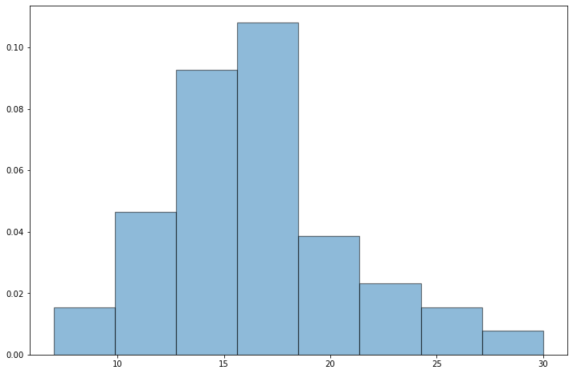

```python
plt.figure(figsize=(12,8))



plt.hist(citations_data["Counts"], bins=8, density=True, edgecolor='black', linewidth=1.2, alpha=0.5)
x = np.arange(30)
```